# Vignette Title

# Homework 9

## Question 1

A-B-O blood type problem

Observed data: nA· = nAA + nAO = 444 (A-type), nB· = nBB + nBO = 132 (B-type), nOO = 361 (O-type), nAB = 63 (AB-type).

Use EM algorithm to solve MLE of p and q (consider missing data nAA and nBB).

Record the values of p and q that maximize the conditional likelihood in each EM steps, calculate the corresponding log-maximum likelihood values (for observed data), are they increasing?

## Answer 1

We can get that

```r
library(nloptr)
eval_f0 = function(x,x1,n.A=444,n.B=132,nOO=361,nAB=63) {

  r1 = 1-sum(x1)
  nAA = n.A*x1[1]^2/(x1[1]^2+2*x1[1]*r1)
  nBB = n.B*x1[2]^2/(x1[2]^2+2*x1[2]*r1)
  r = 1-sum(x)
  return(-2*nAA*log(x[1])-2*nBB*log(x[2])-2*nOO*log(r)-
           (n.A-nAA)*log(2*x[1]*r)-(n.B-nBB)*log(2*x[2]*r)-nAB*log(2*x[1]*x[2]))
}



eval_g0 = function(x,x1,n.A=444,n.B=132,nOO=361,nAB=63) {
  return(sum(x)-0.999999)
}

opts = list("algorithm"="NLOPT_LN_COBYLA",
             "xtol_rel"=1.0e-8)
mle = NULL
r = matrix(0,1,2)
r = rbind(r,c(0.2,0.35))# the beginning value of p0 and q0
j = 2
while (sum(abs(r[j,]-r[j-1,]))>1e-8) {
res = nloptr( x0=c(0.2,0.25),
               eval_f=eval_f0,
               lb = c(0,0), ub = c(1,1),
               eval_g_ineq = eval_g0,
               opts = opts, x1=r[j,],n.A=444,n.B=132,nOO=361,nAB=63 )
j = j+1
r = rbind(r,res$solution)
mle = c(mle,eval_f0(x=r[j,],x1=r[j-1,]))
}

r
```

```
#>            [,1]      [,2]
#>  [1,] 0.0000000 0.0000000
#>  [2,] 0.2000000 0.3500000
#>  [3,] 0.2938636 0.1159800
#>  [4,] 0.2977537 0.1034051
#>  [5,] 0.2977020 0.1027454
#>  [6,] 0.2976539 0.1027089
#>  [7,] 0.2976433 0.1027065
#>  [8,] 0.2976411 0.1027063
#>  [9,] 0.2976407 0.1027063
#> [10,] 0.2976407 0.1027063
#> [11,] 0.2976407 0.1027063
#> [12,] 0.2976407 0.1027063
```

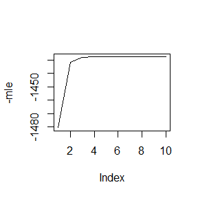

```r
#the max likelihood values
plot(-mle,type = 'l')
```

## Question 2

Use both for loops and lapply() to fit linear models to the mtcars using the formulas stored in this list: formulas <- list( mpg ~ disp, mpg ~ I(1 / disp), mpg ~ disp + wt, mpg ~ I(1 / disp) + wt )

## Answer 2

for loops:

```r
formulas <- list(
mpg ~ disp,
mpg ~ I(1 / disp),
mpg ~ disp + wt,
mpg ~ I(1 / disp) + wt
)

l<-formulas

for(i in 1:4){
  l[[i]]<-lm(formulas[[i]],mtcars)
}

l
```

```
#> [[1]]
#>
#> Call:
#> lm(formula = formulas[[i]], data = mtcars)
#>
#> Coefficients:
#> (Intercept)         disp
#>    29.59985     -0.04122
#>
#>
#> [[2]]
#>
#> Call:
#> lm(formula = formulas[[i]], data = mtcars)
#>
#> Coefficients:
#> (Intercept)    I(1/disp)
#>       10.75      1557.67
#>
#>
#> [[3]]
#>
#> Call:
#> lm(formula = formulas[[i]], data = mtcars)
#>
#> Coefficients:
#> (Intercept)         disp           wt
#>    34.96055     -0.01772     -3.35083
#>
#>
#> [[4]]
#>
#> Call:
#> lm(formula = formulas[[i]], data = mtcars)
#>
#> Coefficients:
#> (Intercept)    I(1/disp)           wt
#>      19.024     1142.560       -1.798
```

lapply():

```r
formulas <- list(
mpg ~ disp,
mpg ~ I(1 / disp),
mpg ~ disp + wt,
mpg ~ I(1 / disp) + wt
)

lapply(formulas,function(formula) lm(formula,mtcars))
```

```
#> [[1]]
#>
#> Call:
#> lm(formula = formula, data = mtcars)
#>
#> Coefficients:
#> (Intercept)         disp
#>    29.59985     -0.04122
#>
#>
#> [[2]]
#>
#> Call:
#> lm(formula = formula, data = mtcars)
#>
#> Coefficients:
#> (Intercept)    I(1/disp)
#>       10.75      1557.67
#>
#>
#> [[3]]
#>
#> Call:
#> lm(formula = formula, data = mtcars)
#>
#> Coefficients:
#> (Intercept)         disp           wt
#>    34.96055     -0.01772     -3.35083
#>
#>
#> [[4]]
#>
#> Call:
#> lm(formula = formula, data = mtcars)
#>
#> Coefficients:
#> (Intercept)    I(1/disp)           wt
#>      19.024     1142.560       -1.798
```

## Question 3

The following code simulates the performance of a t-test for non-normal data. Use sapply() and an anonymous function to extract the p-value from every trial. trials <- replicate( 100, t.test(rpois(10, 10), rpois(7, 10)), simplify = FALSE ) Extra challenge: get rid of the anonymous function by using [[ directly.

## Answer 3

```r
set.seed(12345)
trials <- replicate(100, t.test(rpois(10, 10), rpois(7, 10)),
simplify = FALSE
)
sapply(trials,function(trial) trial$p.value)
```

```
#>   [1] 0.178809502 0.994262402 0.064786264 0.952716251 0.306702525 0.198224877
#>   [7] 0.272315768 0.283722503 0.415010770 0.151957272 0.072625558 0.249014108
#>  [13] 0.773938569 0.225693023 0.840328179 0.987492066 0.316112244 0.481740992
#>  [19] 0.457889571 0.565871989 0.990401857 0.257905112 0.538178810 0.764364559
#>  [25] 0.845551784 0.905726387 0.086725138 0.763639767 0.088857796 0.531422351
#>  [31] 0.731524606 0.195574176 0.598923896 0.702134266 0.147168770 0.552598436
#>  [37] 0.117002585 0.233188724 0.127240002 0.115791872 0.317030411 0.691674119
#>  [43] 0.450514119 0.315343567 0.073583503 1.000000000 0.011099981 0.580714657
#>  [49] 0.591841839 0.638287091 0.283349660 0.722557025 0.408819857 0.127117578
#>  [55] 0.000507563 0.841418067 0.624022112 0.650656602 0.632088219 0.578419158
#>  [61] 0.052008307 0.920025002 0.646534041 0.344836350 0.751638828 0.687324041
#>  [67] 0.134492519 0.490444844 0.711864108 0.020394691 0.342792908 0.960823950
#>  [73] 0.111337525 0.546907007 0.773231299 0.626303636 0.298304108 0.146218612
#>  [79] 0.133931753 0.814393484 0.096839576 0.974929586 0.808056754 0.346709412
#>  [85] 0.308443909 0.600935588 0.984471134 0.703069949 0.678262994 0.565803030
#>  [91] 0.895621651 0.723438333 0.431024548 0.061331285 0.043636182 0.359298038
#>  [97] 0.372409666 0.953012247 0.503028465 0.594358009
```

## Question 4

Implement a combination of Map() and vapply() to create an lapply() variant that iterates in parallel over all of its inputs and stores its outputs in a vector (or a matrix). What arguments should the function take?

## Answer 4

```r
x<-matrix(1:10,nrow = 2)
x
```

```
#>      [,1] [,2] [,3] [,4] [,5]
#> [1,]    1    3    5    7    9
#> [2,]    2    4    6    8   10
```

```r
vapply(x,function(x) as.vector(x),c(1))
```

```
#>  [1]  1  2  3  4  5  6  7  8  9 10
```

# Homework 10

## Question

Write an Rcpp function for Exercise 9.4 (page 277, Statistical Computing with R).

Compare the corresponding generated random numbers with those by the R function you wrote before using the function “qqplot”.

Campare the computation time of the two functions with the function “microbenchmark”.

Comments your results.

## Answer

```r
library(Rcpp)
```

Rcpp function:

```r
#include <Rcpp.h>
using namespace Rcpp;

double lap_f(double x){
  return 0.5 * exp(-abs(x));
}


// [[Rcpp::export]]

NumericVector MetropolisC(double sigma, double x0, int N){
  NumericVector x(N);
  x[0] = x0;
  NumericVector u(N);
  u = runif(N);
  int k = 0;
  for (int i = 1; i < N; ++i){
    NumericVector y(1);
    y = rnorm(1, x[i-1],sigma);
    if ( u[i] <= lap_f(y[0])/lap_f(x[i-1]))
          x[i] = y[0] ;
    else{
          x[i] = x[i-1];
          k = k+1;
    }
  }
  return x;
}
```

```r
set.seed(12345)
lap_f = function(x) exp(-abs(x))

rw.Metropolis = function(sigma, x0, N){
 x = numeric(N)
 x[1] = x0
 u = runif(N)
 k = 0
 for (i in 2:N) {
  y = rnorm(1, x[i-1], sigma)
  if (u[i] <= (lap_f(y) / lap_f(x[i-1]))) x[i] = y
  else {
  x[i] = x[i-1]
  k = k+1
  }
 }
 return(list(x = x, k = k))
}


dir_cpp <- '../src/'

sourceCpp(paste0(dir_cpp,"Homework.cpp"))
n<-4
N<-2000
sigma<-c(0.05,0.5,2,16)

x0<-25
rw1c<-MetropolisC(sigma[1],x0,N)
rw2c<-MetropolisC(sigma[2],x0,N)
rw3c<-MetropolisC(sigma[3],x0,N)
rw4c<-MetropolisC(sigma[4],x0,N)
rw1<-rw.Metropolis(sigma[1],x0,N)
rw2<-rw.Metropolis(sigma[2],x0,N)
rw3<-rw.Metropolis(sigma[3],x0,N)
rw4<-rw.Metropolis(sigma[4],x0,N)
```

Compare the corresponding generated random numbers with those by R function:

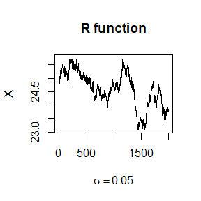

```r
plot(rw1$x,type="l",xlab=bquote(sigma==0.05),ylab="X",main="R function")
```

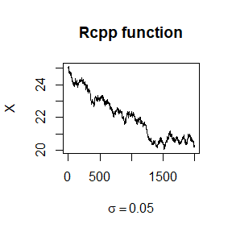

```r
plot(rw1c,type="l",xlab=bquote(sigma==0.05),ylab="X",main="Rcpp function")
```

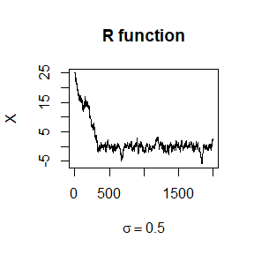

```r
plot(rw2$x,type="l",xlab=bquote(sigma==0.5),ylab="X",main="R function")
```

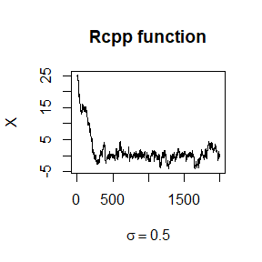

```r
plot(rw2c,type="l",xlab=bquote(sigma==0.5),ylab="X",main="Rcpp function")
```

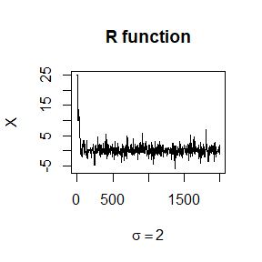

```r
plot(rw3$x,type="l",xlab=bquote(sigma==2),ylab="X",main="R function")
```

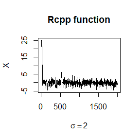

```r
plot(rw3c,type="l",xlab=bquote(sigma==2),ylab="X",main="Rcpp function")
```

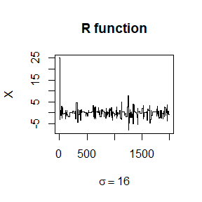

```r
plot(rw4$x,type="l",xlab=bquote(sigma==16),ylab="X",main="R function")
```

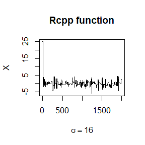

```r
plot(rw4c,type="l",xlab=bquote(sigma==16),ylab="X",main="Rcpp function")
```

Campare the computation time of the two functions with the function “microbenchmark”.

```r
library(microbenchmark)
ts1 <- microbenchmark(rw1R=rw.Metropolis(sigma[1],x0,N),rw1C=MetropolisC(sigma[1],x0,N))
summary(ts1)[,c(1,3,5,6)]
```

```
#>   expr      lq median     uq
#> 1 rw1R 8401.80 8461.5 8679.0
#> 2 rw1C  586.05  594.8  603.2
```

```r
ts2 <- microbenchmark(rw2R=rw.Metropolis(sigma[2],x0,N),rw2C=MetropolisC(sigma[2],x0,N))
summary(ts2)[,c(1,3,5,6)]
```

```
#>   expr      lq  median     uq
#> 1 rw2R 8405.65 8448.25 8495.0
#> 2 rw2C  634.80  640.70  646.8
```

```r
ts3 <- microbenchmark(rw3R=rw.Metropolis(sigma[3],x0,N),rw3C=MetropolisC(sigma[3],x0,N))
summary(ts3)[,c(1,3,5,6)]
```

```
#>   expr      lq  median      uq
#> 1 rw3R 8459.45 8503.80 8610.90
#> 2 rw3C  637.90  643.35  653.25
```

```r
ts4 <- microbenchmark(rw4R=rw.Metropolis(sigma[4],x0,N),rw4C=MetropolisC(sigma[4],x0,N))
summary(ts4)[,c(1,3,5,6)]
```

```
#>   expr     lq  median      uq
#> 1 rw4R 8475.0 8533.75 8610.75
#> 2 rw4C  614.7  619.10  625.10
```

We can see that with each sigma, the Rcpp function runs much faster than the R function.